# What is calculus?

### What is calculus?

- Ask students who has taken calculus already. What's it about? They will say “integrals” and “derivatives.” Ask them what these are for? When they say “areas,” ask how often they have a problem involving areas (outside of a math course). Why are areas so important, then?
- A strategy for turning descriptions of parts into wholes, and for taking wholes apart into parts. *Sometimes it's easy to describe things in terms of parts. Examples: Whole: What's the size of the US economy? (Few people can say.) What's the growth rate? (Many people know something reasonable.) Whole: What will be the population in 2050? Part: How many people will be born and will die this year? Whole: How many people will get the flu? Part: For each person who gets the flu, how many new people, on average, will catch it from him or her?
- Ask what the word “calculus” means.

### A little of the history of calculus

- Method of exhaustion and limits from 400-200BC. Example problem: What's the area of a circle?

[figure not shown]

Method of Exhaustion

- Newton's book from 1736. Note the vocabulary: functions or variables are “fluents”, derivatives are “fluxions”:

Newton's Calculus Book

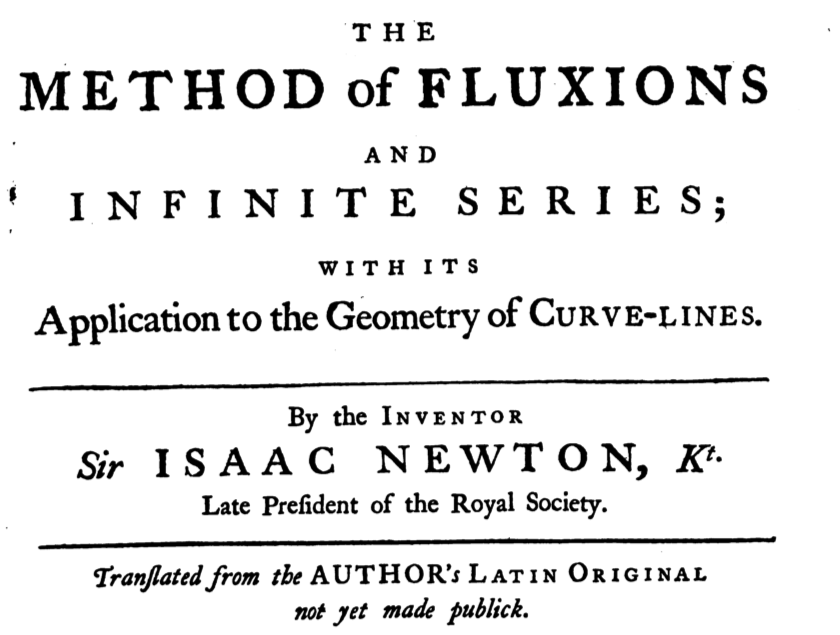

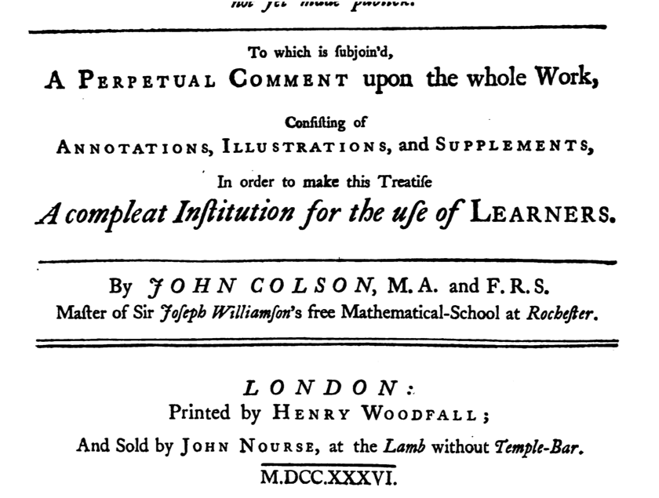

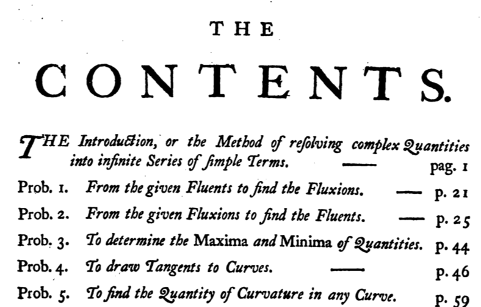

An important part of mathematical calculus is about exactitude and precise statement. But starting with Newton, calculus became a language for describing the world, one that formalizes the distinction between “change” and “state.” The emphasis of this course is on the uses for calculus in describing, creating representations of parts of the real world that are of broad interest, and using those representations to extract useful information: Modeling.

### Advising en masse: Should you be in this course?

- If you are prepared to take Single Variable or Multivariable, and you will eventually take multivariable or linear algebra, then you don't necessarily need to be in this course.

### The Strategy of Calculus

Information comes in different forms. One form is “position.” Another form is “change.” Calculus provides tools for relating the two with the insight that “change” can be *accumulated* to give position, and “position” can be *differentiated* to give change.

### Review of the topics of the course

Central themes: modeling and computation, both symbolic and numeric.

1. Functions and Computing with Runctions
2. Units, Dimensions, Scaling, and Estimation
3. Linear Algebra
4. Derivatives and Integrals
5. Optimization
6. Differential equations
7. Quick introduction to R and RStudio: *Start R in Calculus*